# FinalProjectIntroToBA-final

Step 1. Load Data

```python
#read in_time.csv and out_time.csv
import pandas as pd
in_time = pd.read_csv('in_time.csv')
out_time = pd.read_csv('out_time.csv')
```

```python
#rename first column to 'id'
in_time.rename(columns={'Unnamed: 0':'id'}, inplace=True)
in_time.iloc[:,1:] = in_time.iloc[:,1:].apply(pd.to_datetime)
in_time.head()
```

|  | id | 2015-01-01 | 2015-01-02 | 2015-01-05 | 2015-01-06 | 2015-01-07 | 2015-01-08 | 2015-01-09 | 2015-01-12 | 2015-01-13 | ... | 2015-12-18 | 2015-12-21 | 2015-12-22 | 2015-12-23 | 2015-12-24 | 2015-12-25 | 2015-12-28 | 2015-12-29 | 2015-12-30 | 2015-12-31 |
| --- | --- | --- | --- | --- | --- | --- | --- | --- | --- | --- | --- | --- | --- | --- | --- | --- | --- | --- | --- | --- | --- |
| 0 | 1 | NaT | 2015-01-02 09:43:45 | 2015-01-05 10:08:48 | 2015-01-06 09:54:26 | 2015-01-07 09:34:31 | 2015-01-08 09:51:09 | 2015-01-09 10:09:25 | 2015-01-12 09:42:53 | 2015-01-13 10:13:06 | ... | NaT | 2015-12-21 09:55:29 | 2015-12-22 10:04:06 | 2015-12-23 10:14:27 | 2015-12-24 10:11:35 | NaT | 2015-12-28 10:13:41 | 2015-12-29 10:03:36 | 2015-12-30 09:54:12 | 2015-12-31 10:12:44 |
| 1 | 2 | NaT | 2015-01-02 10:15:44 | 2015-01-05 10:21:05 | NaT | 2015-01-07 09:45:17 | 2015-01-08 10:09:04 | 2015-01-09 09:43:26 | 2015-01-12 10:00:07 | 2015-01-13 10:43:29 | ... | 2015-12-18 10:37:17 | 2015-12-21 09:49:02 | 2015-12-22 10:33:51 | 2015-12-23 10:12:10 | NaT | NaT | 2015-12-28 09:31:45 | 2015-12-29 09:55:49 | 2015-12-30 10:32:25 | 2015-12-31 09:27:20 |
| 2 | 3 | NaT | 2015-01-02 10:17:41 | 2015-01-05 09:50:50 | 2015-01-06 10:14:13 | 2015-01-07 09:47:27 | 2015-01-08 10:03:40 | 2015-01-09 10:05:49 | 2015-01-12 10:03:47 | 2015-01-13 10:21:26 | ... | 2015-12-18 10:15:14 | 2015-12-21 10:10:28 | 2015-12-22 09:44:44 | 2015-12-23 10:15:54 | 2015-12-24 10:07:26 | NaT | 2015-12-28 09:42:05 | 2015-12-29 09:43:36 | 2015-12-30 09:34:05 | 2015-12-31 10:28:39 |
| 3 | 4 | NaT | 2015-01-02 10:05:06 | 2015-01-05 09:56:32 | 2015-01-06 10:11:07 | 2015-01-07 09:37:30 | 2015-01-08 10:02:08 | 2015-01-09 10:08:12 | 2015-01-12 10:13:42 | 2015-01-13 09:53:22 | ... | 2015-12-18 10:17:38 | 2015-12-21 09:58:21 | 2015-12-22 10:04:25 | 2015-12-23 10:11:46 | 2015-12-24 09:43:15 | NaT | 2015-12-28 09:52:44 | 2015-12-29 09:33:16 | 2015-12-30 10:18:12 | 2015-12-31 10:01:15 |
| 4 | 5 | NaT | 2015-01-02 10:28:17 | 2015-01-05 09:49:58 | 2015-01-06 09:45:28 | 2015-01-07 09:49:37 | 2015-01-08 10:19:44 | 2015-01-09 10:00:50 | 2015-01-12 10:29:27 | 2015-01-13 09:59:32 | ... | 2015-12-18 09:58:35 | 2015-12-21 10:03:41 | 2015-12-22 10:10:30 | 2015-12-23 10:13:36 | 2015-12-24 09:44:24 | NaT | 2015-12-28 10:05:15 | 2015-12-29 10:30:53 | 2015-12-30 09:18:21 | 2015-12-31 09:41:09 |

5 rows × 262 columns

```python
#rename first column to 'id'
out_time.rename(columns={'Unnamed: 0':'id'}, inplace=True)
#convert all columns but 'id' to datetime
out_time.iloc[:,1:] = out_time.iloc[:,1:].apply(pd.to_datetime)
out_time.head()
```

|  | id | 2015-01-01 | 2015-01-02 | 2015-01-05 | 2015-01-06 | 2015-01-07 | 2015-01-08 | 2015-01-09 | 2015-01-12 | 2015-01-13 | ... | 2015-12-18 | 2015-12-21 | 2015-12-22 | 2015-12-23 | 2015-12-24 | 2015-12-25 | 2015-12-28 | 2015-12-29 | 2015-12-30 | 2015-12-31 |
| --- | --- | --- | --- | --- | --- | --- | --- | --- | --- | --- | --- | --- | --- | --- | --- | --- | --- | --- | --- | --- | --- |
| 0 | 1 | NaT | 2015-01-02 16:56:15 | 2015-01-05 17:20:11 | 2015-01-06 17:19:05 | 2015-01-07 16:34:55 | 2015-01-08 17:08:32 | 2015-01-09 17:38:29 | 2015-01-12 16:58:39 | 2015-01-13 18:02:58 | ... | NaT | 2015-12-21 17:15:50 | 2015-12-22 17:27:51 | 2015-12-23 16:44:44 | 2015-12-24 17:47:22 | NaT | 2015-12-28 18:00:07 | 2015-12-29 17:22:30 | 2015-12-30 17:40:56 | 2015-12-31 17:17:33 |
| 1 | 2 | NaT | 2015-01-02 18:22:17 | 2015-01-05 17:48:22 | NaT | 2015-01-07 17:09:06 | 2015-01-08 17:34:04 | 2015-01-09 16:52:29 | 2015-01-12 17:36:48 | 2015-01-13 18:00:13 | ... | 2015-12-18 18:31:28 | 2015-12-21 17:34:16 | 2015-12-22 18:16:35 | 2015-12-23 17:38:18 | NaT | NaT | 2015-12-28 17:08:38 | 2015-12-29 17:54:46 | 2015-12-30 18:31:35 | 2015-12-31 17:40:58 |
| 2 | 3 | NaT | 2015-01-02 16:59:14 | 2015-01-05 17:06:46 | 2015-01-06 16:38:32 | 2015-01-07 16:33:21 | 2015-01-08 17:24:22 | 2015-01-09 16:57:30 | 2015-01-12 17:28:54 | 2015-01-13 17:21:25 | ... | 2015-12-18 17:02:23 | 2015-12-21 17:20:17 | 2015-12-22 16:32:50 | 2015-12-23 16:59:43 | 2015-12-24 16:58:25 | NaT | 2015-12-28 16:43:31 | 2015-12-29 17:09:56 | 2015-12-30 17:06:25 | 2015-12-31 17:15:50 |
| 3 | 4 | NaT | 2015-01-02 17:25:24 | 2015-01-05 17:14:03 | 2015-01-06 17:07:42 | 2015-01-07 16:32:40 | 2015-01-08 16:53:11 | 2015-01-09 17:19:47 | 2015-01-12 17:13:37 | 2015-01-13 17:11:45 | ... | 2015-12-18 17:55:23 | 2015-12-21 16:49:09 | 2015-12-22 17:24:00 | 2015-12-23 17:36:35 | 2015-12-24 16:48:21 | NaT | 2015-12-28 17:19:34 | 2015-12-29 16:58:16 | 2015-12-30 17:40:11 | 2015-12-31 17:09:14 |
| 4 | 5 | NaT | 2015-01-02 18:31:37 | 2015-01-05 17:49:15 | 2015-01-06 17:26:25 | 2015-01-07 17:37:59 | 2015-01-08 17:59:28 | 2015-01-09 17:44:08 | 2015-01-12 18:51:21 | 2015-01-13 18:14:58 | ... | 2015-12-18 17:52:48 | 2015-12-21 17:43:35 | 2015-12-22 18:07:57 | 2015-12-23 18:00:49 | 2015-12-24 17:59:22 | NaT | 2015-12-28 17:44:59 | 2015-12-29 18:47:00 | 2015-12-30 17:15:33 | 2015-12-31 17:42:14 |

5 rows × 262 columns

```python
# create a df of the time difference between all columns and rows with matching indexes in_time and out_time
time_diff = pd.DataFrame(out_time.values - in_time.values, columns=in_time.columns, index=in_time.index)
time_diff['id'] = in_time['id']
time_diff.head()
```

|  | id | 2015-01-01 | 2015-01-02 | 2015-01-05 | 2015-01-06 | 2015-01-07 | 2015-01-08 | 2015-01-09 | 2015-01-12 | 2015-01-13 | ... | 2015-12-18 | 2015-12-21 | 2015-12-22 | 2015-12-23 | 2015-12-24 | 2015-12-25 | 2015-12-28 | 2015-12-29 | 2015-12-30 | 2015-12-31 |
| --- | --- | --- | --- | --- | --- | --- | --- | --- | --- | --- | --- | --- | --- | --- | --- | --- | --- | --- | --- | --- | --- |
| 0 | 1 | NaT | 0 days 07:12:30 | 0 days 07:11:23 | 0 days 07:24:39 | 0 days 07:00:24 | 0 days 07:17:23 | 0 days 07:29:04 | 0 days 07:15:46 | 0 days 07:49:52 | ... | NaT | 0 days 07:20:21 | 0 days 07:23:45 | 0 days 06:30:17 | 0 days 07:35:47 | NaT | 0 days 07:46:26 | 0 days 07:18:54 | 0 days 07:46:44 | 0 days 07:04:49 |
| 1 | 2 | NaT | 0 days 08:06:33 | 0 days 07:27:17 | NaT | 0 days 07:23:49 | 0 days 07:25:00 | 0 days 07:09:03 | 0 days 07:36:41 | 0 days 07:16:44 | ... | 0 days 07:54:11 | 0 days 07:45:14 | 0 days 07:42:44 | 0 days 07:26:08 | NaT | NaT | 0 days 07:36:53 | 0 days 07:58:57 | 0 days 07:59:10 | 0 days 08:13:38 |
| 2 | 3 | NaT | 0 days 06:41:33 | 0 days 07:15:56 | 0 days 06:24:19 | 0 days 06:45:54 | 0 days 07:20:42 | 0 days 06:51:41 | 0 days 07:25:07 | 0 days 06:59:59 | ... | 0 days 06:47:09 | 0 days 07:09:49 | 0 days 06:48:06 | 0 days 06:43:49 | 0 days 06:50:59 | NaT | 0 days 07:01:26 | 0 days 07:26:20 | 0 days 07:32:20 | 0 days 06:47:11 |
| 3 | 4 | NaT | 0 days 07:20:18 | 0 days 07:17:31 | 0 days 06:56:35 | 0 days 06:55:10 | 0 days 06:51:03 | 0 days 07:11:35 | 0 days 06:59:55 | 0 days 07:18:23 | ... | 0 days 07:37:45 | 0 days 06:50:48 | 0 days 07:19:35 | 0 days 07:24:49 | 0 days 07:05:06 | NaT | 0 days 07:26:50 | 0 days 07:25:00 | 0 days 07:21:59 | 0 days 07:07:59 |
| 4 | 5 | NaT | 0 days 08:03:20 | 0 days 07:59:17 | 0 days 07:40:57 | 0 days 07:48:22 | 0 days 07:39:44 | 0 days 07:43:18 | 0 days 08:21:54 | 0 days 08:15:26 | ... | 0 days 07:54:13 | 0 days 07:39:54 | 0 days 07:57:27 | 0 days 07:47:13 | 0 days 08:14:58 | NaT | 0 days 07:39:44 | 0 days 08:16:07 | 0 days 07:57:12 | 0 days 08:01:05 |

5 rows × 262 columns

```python
#convert all columns but 'id' from datetime to number of hours
for i in range(1, len(time_diff.columns)):
    time_diff.iloc[:,i] = time_diff.iloc[:,i].apply(lambda x: x.total_seconds()/3600)

time_diff.head()
```

|  | id | 2015-01-01 | 2015-01-02 | 2015-01-05 | 2015-01-06 | 2015-01-07 | 2015-01-08 | 2015-01-09 | 2015-01-12 | 2015-01-13 | ... | 2015-12-18 | 2015-12-21 | 2015-12-22 | 2015-12-23 | 2015-12-24 | 2015-12-25 | 2015-12-28 | 2015-12-29 | 2015-12-30 | 2015-12-31 |
| --- | --- | --- | --- | --- | --- | --- | --- | --- | --- | --- | --- | --- | --- | --- | --- | --- | --- | --- | --- | --- | --- |
| 0 | 1 | NaN | 7.208333 | 7.189722 | 7.410833 | 7.006667 | 7.289722 | 7.484444 | 7.262778 | 7.831111 | ... | NaN | 7.339167 | 7.395833 | 6.504722 | 7.596389 | NaN | 7.773889 | 7.315000 | 7.778889 | 7.080278 |
| 1 | 2 | NaN | 8.109167 | 7.454722 | NaN | 7.396944 | 7.416667 | 7.150833 | 7.611389 | 7.278889 | ... | 7.903056 | 7.753889 | 7.712222 | 7.435556 | NaN | NaN | 7.614722 | 7.982500 | 7.986111 | 8.227222 |
| 2 | 3 | NaN | 6.692500 | 7.265556 | 6.405278 | 6.765000 | 7.345000 | 6.861389 | 7.418611 | 6.999722 | ... | 6.785833 | 7.163611 | 6.801667 | 6.730278 | 6.849722 | NaN | 7.023889 | 7.438889 | 7.538889 | 6.786389 |
| 3 | 4 | NaN | 7.338333 | 7.291944 | 6.943056 | 6.919444 | 6.850833 | 7.193056 | 6.998611 | 7.306389 | ... | 7.629167 | 6.846667 | 7.326389 | 7.413611 | 7.085000 | NaN | 7.447222 | 7.416667 | 7.366389 | 7.133056 |
| 4 | 5 | NaN | 8.055556 | 7.988056 | 7.682500 | 7.806111 | 7.662222 | 7.721667 | 8.365000 | 8.257222 | ... | 7.903611 | 7.665000 | 7.957500 | 7.786944 | 8.249444 | NaN | 7.662222 | 8.268611 | 7.953333 | 8.018056 |

5 rows × 262 columns

```python
#averge the time difference for each id
time_diff['avg_time'] = time_diff.iloc[:,1:].mean(axis=1)
time_diff[['avg_time', 'id']].to_csv('avg_time_diff.csv', index=False)
time_diff[['avg_time', 'id']].head(10)

actual_work_time = time_diff[['avg_time', 'id']]
```

```python
#load general_data
general_data = pd.read_csv('general_data.csv')
```

```python
#creating 'id'
general_data['id'] = general_data.index + 1

# Reorder the columns to make 'row_id' the first column
general_data = general_data[['id'] + [col for col in general_data.columns if col != 'id']]

general_data.head()
```

|  | id | Age | Attrition | BusinessTravel | Department | DistanceFromHome | Education | EducationField | EmployeeCount | EmployeeID | ... | NumCompaniesWorked | Over18 | PercentSalaryHike | StandardHours | StockOptionLevel | TotalWorkingYears | TrainingTimesLastYear | YearsAtCompany | YearsSinceLastPromotion | YearsWithCurrManager |
| --- | --- | --- | --- | --- | --- | --- | --- | --- | --- | --- | --- | --- | --- | --- | --- | --- | --- | --- | --- | --- | --- |
| 0 | 1 | 51 | No | Travel_Rarely | Sales | 6 | 2 | Life Sciences | 1 | 1 | ... | 1.0 | Y | 11 | 8 | 0 | 1.0 | 6 | 1 | 0 | 0 |
| 1 | 2 | 31 | Yes | Travel_Frequently | Research & Development | 10 | 1 | Life Sciences | 1 | 2 | ... | 0.0 | Y | 23 | 8 | 1 | 6.0 | 3 | 5 | 1 | 4 |
| 2 | 3 | 32 | No | Travel_Frequently | Research & Development | 17 | 4 | Other | 1 | 3 | ... | 1.0 | Y | 15 | 8 | 3 | 5.0 | 2 | 5 | 0 | 3 |
| 3 | 4 | 38 | No | Non-Travel | Research & Development | 2 | 5 | Life Sciences | 1 | 4 | ... | 3.0 | Y | 11 | 8 | 3 | 13.0 | 5 | 8 | 7 | 5 |
| 4 | 5 | 32 | No | Travel_Rarely | Research & Development | 10 | 1 | Medical | 1 | 5 | ... | 4.0 | Y | 12 | 8 | 2 | 9.0 | 2 | 6 | 0 | 4 |

5 rows × 25 columns

```python
#join table
df = pd.merge(general_data, actual_work_time, on='id', how='left')
```

Step 2. Data Exploration

```python
df.describe()
```

|  | id | Age | DistanceFromHome | Education | EmployeeCount | EmployeeID | JobLevel | MonthlyIncome | NumCompaniesWorked | PercentSalaryHike | StandardHours | StockOptionLevel | TotalWorkingYears | TrainingTimesLastYear | YearsAtCompany | YearsSinceLastPromotion | YearsWithCurrManager | avg_time |
| --- | --- | --- | --- | --- | --- | --- | --- | --- | --- | --- | --- | --- | --- | --- | --- | --- | --- | --- |
| count | 4410.000000 | 4410.000000 | 4410.000000 | 4410.000000 | 4410.0 | 4410.000000 | 4410.000000 | 4410.000000 | 4391.000000 | 4410.000000 | 4410.0 | 4410.000000 | 4401.000000 | 4410.000000 | 4410.000000 | 4410.000000 | 4410.000000 | 4410.000000 |
| mean | 2205.500000 | 36.923810 | 9.192517 | 2.912925 | 1.0 | 2205.500000 | 2.063946 | 65029.312925 | 2.694830 | 15.209524 | 8.0 | 0.793878 | 11.279936 | 2.799320 | 7.008163 | 2.187755 | 4.123129 | 7.700792 |
| std | 1273.201673 | 9.133301 | 8.105026 | 1.023933 | 0.0 | 1273.201673 | 1.106689 | 47068.888559 | 2.498887 | 3.659108 | 0.0 | 0.851883 | 7.782222 | 1.288978 | 6.125135 | 3.221699 | 3.567327 | 1.340218 |
| min | 1.000000 | 18.000000 | 1.000000 | 1.000000 | 1.0 | 1.000000 | 1.000000 | 10090.000000 | 0.000000 | 11.000000 | 8.0 | 0.000000 | 0.000000 | 0.000000 | 0.000000 | 0.000000 | 0.000000 | 5.950504 |
| 25% | 1103.250000 | 30.000000 | 2.000000 | 2.000000 | 1.0 | 1103.250000 | 1.000000 | 29110.000000 | 1.000000 | 12.000000 | 8.0 | 0.000000 | 6.000000 | 2.000000 | 3.000000 | 0.000000 | 2.000000 | 6.673333 |
| 50% | 2205.500000 | 36.000000 | 7.000000 | 3.000000 | 1.0 | 2205.500000 | 2.000000 | 49190.000000 | 2.000000 | 14.000000 | 8.0 | 1.000000 | 10.000000 | 3.000000 | 5.000000 | 1.000000 | 3.000000 | 7.406761 |
| 75% | 3307.750000 | 43.000000 | 14.000000 | 4.000000 | 1.0 | 3307.750000 | 3.000000 | 83800.000000 | 4.000000 | 18.000000 | 8.0 | 1.000000 | 15.000000 | 3.000000 | 9.000000 | 3.000000 | 7.000000 | 8.368703 |
| max | 4410.000000 | 60.000000 | 29.000000 | 5.000000 | 1.0 | 4410.000000 | 5.000000 | 199990.000000 | 9.000000 | 25.000000 | 8.0 | 3.000000 | 40.000000 | 6.000000 | 40.000000 | 15.000000 | 17.000000 | 11.030960 |

```python
df.info()
```

```
<class 'pandas.core.frame.DataFrame'>
Int64Index: 4410 entries, 0 to 4409
Data columns (total 26 columns):
 #   Column                   Non-Null Count  Dtype
---  ------                   --------------  -----
 0   id                       4410 non-null   int64
 1   Age                      4410 non-null   int64
 2   Attrition                4410 non-null   object
 3   BusinessTravel           4410 non-null   object
 4   Department               4410 non-null   object
 5   DistanceFromHome         4410 non-null   int64
 6   Education                4410 non-null   int64
 7   EducationField           4410 non-null   object
 8   EmployeeCount            4410 non-null   int64
 9   EmployeeID               4410 non-null   int64
```

[output cut: 18 more lines]

```python
# Calculate skewness for each column
skewness_scores = df.skew(numeric_only=True)

# Print or return the skewness scores
print(skewness_scores)
```

```
id                         0.000000
Age                        0.413005
DistanceFromHome           0.957466
Education                 -0.289484
EmployeeCount              0.000000
EmployeeID                 0.000000
JobLevel                   1.024703
MonthlyIncome              1.368884
NumCompaniesWorked         1.026767
PercentSalaryHike          0.820569
StandardHours              0.000000
StockOptionLevel           0.968321
TotalWorkingYears          1.116832
TrainingTimesLastYear      0.552748
YearsAtCompany             1.763328
YearsSinceLastPromotion    1.982939
YearsWithCurrManager       0.832884
avg_time                   0.863133
dtype: float64
```

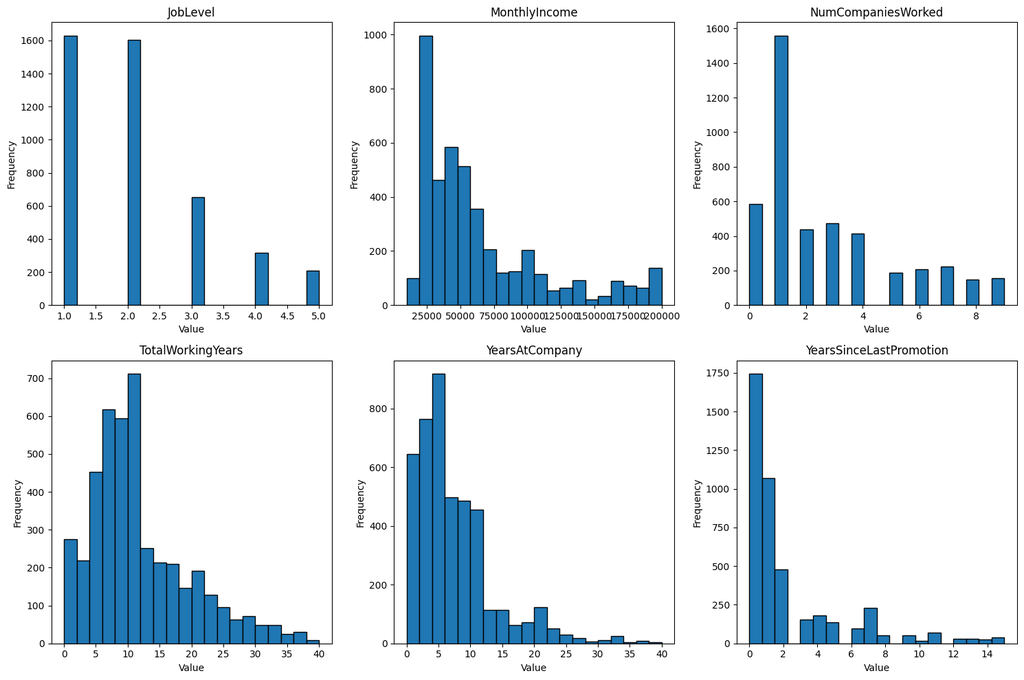

```python
#check the SE variables which are highly skewed
import matplotlib.pyplot as plt

columns_to_check = ['JobLevel', 'MonthlyIncome', 'NumCompaniesWorked', 'TotalWorkingYears', 'YearsAtCompany', 'YearsSinceLastPromotion']

# Create a figure with subplots in a 2x3 grid
fig, axes = plt.subplots(nrows=2, ncols=3, figsize=(15, 10))

# Iterate through columns and plot histograms
for i, column in enumerate(columns_to_check):
    ax = axes[i // 3, i % 3]  # Convert linear index to 2D
    ax.hist(df[column], bins=20, edgecolor='k')
    ax.set_title(column)
    ax.set_xlabel('Value')
    ax.set_ylabel('Frequency')

plt.tight_layout()
plt.show()
```

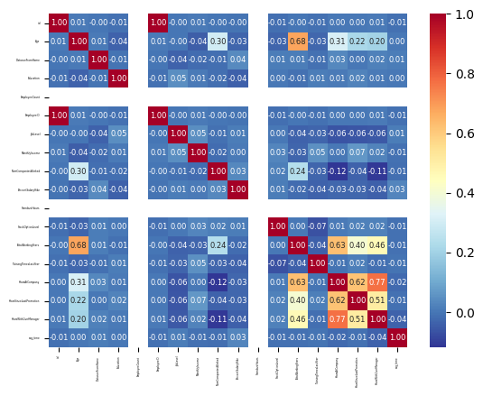

```python
import seaborn as sns
import numpy as np
import matplotlib.pyplot as plt

# Exclude non-numeric columns from the correlation matrix
numeric_df = df.select_dtypes(include=[np.number])

# Plot heatmap
ax = sns.heatmap(numeric_df.corr(), annot=True, fmt=".2f", cmap='RdYlBu_r', annot_kws={"size": 6})

# Adjust size of column and row labels
ax.tick_params(axis='both', which='major', labelsize=2)

plt.show()
```

### encoding categorical variables

```python
# binary gender directly replace
df['Gender'].value_counts()
```

```
Male      2646
Female    1764
Name: Gender, dtype: int64
```

```python
df['Gender'] = df['Gender'].replace({'Male': 1, 'Female': 0})
df['Over18'] = df['Over18'].replace({'Y': 1, 'N': 0})
```

```python
df['BusinessTravel'].value_counts()
```

```
Travel_Rarely        3129
Travel_Frequently     831
Non-Travel            450
Name: BusinessTravel, dtype: int64
```

```python
df['MaritalStatus'].value_counts()
```

```
Married     2019
Single      1410
Divorced     981
Name: MaritalStatus, dtype: int64
```

```python
df['Department'].value_counts()
```

```
Research & Development    2883
Sales                     1338
Human Resources            189
Name: Department, dtype: int64
```

```python
df['EducationField'].value_counts()
```

```
Life Sciences       1818
Medical             1392
Marketing            477
Technical Degree     396
Other                246
Human Resources       81
Name: EducationField, dtype: int64
```

```python
df['JobRole'].value_counts()
```

```
Sales Executive              978
Research Scientist           876
Laboratory Technician        777
Manufacturing Director       435
Healthcare Representative    393
Manager                      306
Sales Representative         249
Research Director            240
Human Resources              156
Name: JobRole, dtype: int64
```

'BusinessTravel' is ordinal so use Label Encoding: Convert each category to a unique integer. This approach is suitable for ordinal categorical variables where there is an inherent order

'Department', 'JobRole', 'MaritalStatus' and 'EducationField' are not ordinal so use One-Hot Encoding: Convert each categorical feature into binary (0 or 1) columns for each category. This approach is suitable when there is no ordinal relationship between categories.

```python
df['BusinessTravel'] = df['BusinessTravel'].replace({'Non-Travel': 1, 'Travel_Rarely': 2,'Travel_Frequently':3})
```

```python
from sklearn.preprocessing import OneHotEncoder
encoder = OneHotEncoder()
encoded_data = encoder.fit_transform(df[['Department']]) #One-hot encoding converts categorical data into a format that can be provided to machine learning algorithms.
```

```python
pd.DataFrame(encoded_data.toarray(), columns=encoder.get_feature_names_out(['Department']))
```

|  | Department_Human Resources | Department_Research & Development | Department_Sales |
| --- | --- | --- | --- |
| 0 | 0.0 | 0.0 | 1.0 |
| 1 | 0.0 | 1.0 | 0.0 |
| 2 | 0.0 | 1.0 | 0.0 |
| 3 | 0.0 | 1.0 | 0.0 |
| 4 | 0.0 | 1.0 | 0.0 |
| ... | ... | ... | ... |
| 4405 | 0.0 | 1.0 | 0.0 |
| 4406 | 0.0 | 1.0 | 0.0 |
| 4407 | 0.0 | 1.0 | 0.0 |
| 4408 | 0.0 | 0.0 | 1.0 |
| 4409 | 0.0 | 1.0 | 0.0 |

4410 rows × 3 columns

```python
encoder2 = OneHotEncoder()
encoded_data2 = encoder2.fit_transform(df[['EducationField']])
encoder3 = OneHotEncoder()
encoded_data3 = encoder3.fit_transform(df[['MaritalStatus']])
encoder4 = OneHotEncoder()
encoded_data4 = encoder4.fit_transform(df[['JobRole']])
```

```python
df = pd.concat((df, pd.DataFrame(encoded_data.toarray(), columns=encoder.get_feature_names_out(['Department']))), axis=1)
df = pd.concat((df, pd.DataFrame(encoded_data2.toarray(), columns=encoder2.get_feature_names_out(['EducationField']))), axis=1)
df = pd.concat((df, pd.DataFrame(encoded_data3.toarray(), columns=encoder3.get_feature_names_out(['MaritalStatus']))), axis=1)
df = pd.concat((df, pd.DataFrame(encoded_data4.toarray(), columns=encoder4.get_feature_names_out(['JobRole']))), axis=1)
```

```python
#drop the columns of reference level for each categorical feature

df.drop('Department_Research & Development',axis=1,inplace = True)
df.drop('EducationField_Other',axis=1,inplace = True)
df.drop('MaritalStatus_Single',axis=1,inplace = True)
df.drop('JobRole_Manager',axis=1,inplace = True)
```

```python
df.head()
```

|  | id | Age | Attrition | BusinessTravel | Department | DistanceFromHome | Education | EducationField | EmployeeCount | EmployeeID | ... | MaritalStatus_Divorced | MaritalStatus_Married | JobRole_Healthcare Representative | JobRole_Human Resources | JobRole_Laboratory Technician | JobRole_Manufacturing Director | JobRole_Research Director | JobRole_Research Scientist | JobRole_Sales Executive | JobRole_Sales Representative |
| --- | --- | --- | --- | --- | --- | --- | --- | --- | --- | --- | --- | --- | --- | --- | --- | --- | --- | --- | --- | --- | --- |
| 0 | 1 | 51 | No | 2 | Sales | 6 | 2 | Life Sciences | 1 | 1 | ... | 0.0 | 1.0 | 1.0 | 0.0 | 0.0 | 0.0 | 0.0 | 0.0 | 0.0 | 0.0 |
| 1 | 2 | 31 | Yes | 3 | Research & Development | 10 | 1 | Life Sciences | 1 | 2 | ... | 0.0 | 0.0 | 0.0 | 0.0 | 0.0 | 0.0 | 0.0 | 1.0 | 0.0 | 0.0 |
| 2 | 3 | 32 | No | 3 | Research & Development | 17 | 4 | Other | 1 | 3 | ... | 0.0 | 1.0 | 0.0 | 0.0 | 0.0 | 0.0 | 0.0 | 0.0 | 1.0 | 0.0 |
| 3 | 4 | 38 | No | 1 | Research & Development | 2 | 5 | Life Sciences | 1 | 4 | ... | 0.0 | 1.0 | 0.0 | 1.0 | 0.0 | 0.0 | 0.0 | 0.0 | 0.0 | 0.0 |
| 4 | 5 | 32 | No | 2 | Research & Development | 10 | 1 | Medical | 1 | 5 | ... | 0.0 | 0.0 | 0.0 | 0.0 | 0.0 | 0.0 | 0.0 | 0.0 | 1.0 | 0.0 |

5 rows × 43 columns

```python
df.shape
```

```
(4410, 43)
```

```python
df.isna().sum() #19 NAs in NumCompaniesWorked
```

```
id                                    0
Age                                   0
Attrition                             0
BusinessTravel                        0
Department                            0
DistanceFromHome                      0
Education                             0
EducationField                        0
EmployeeCount                         0
EmployeeID                            0
Gender                                0
JobLevel                              0
JobRole                               0
MaritalStatus                         0
MonthlyIncome                         0
NumCompaniesWorked                   19
Over18                                0
PercentSalaryHike                     0
StandardHours                         0
StockOptionLevel                      0
TotalWorkingYears                     9
TrainingTimesLastYear                 0
YearsAtCompany                        0
YearsSinceLastPromotion               0
YearsWithCurrManager                  0
avg_time                              0
Department_Human Resources            0
Department_Sales                      0
EducationField_Human Resources        0
EducationField_Life Sciences          0
EducationField_Marketing              0
EducationField_Medical                0
EducationField_Technical Degree       0
MaritalStatus_Divorced                0
MaritalStatus_Married                 0
JobRole_Healthcare Representative     0
JobRole_Human Resources               0
JobRole_Laboratory Technician         0
JobRole_Manufacturing Director        0
JobRole_Research Director             0
JobRole_Research Scientist            0
JobRole_Sales Executive               0
JobRole_Sales Representative          0
dtype: int64
```

```python
df.dropna(inplace=True)
```

Outliers

```python
# Coninuous variables columns
cont_cols = ['DistanceFromHome', 'MonthlyIncome', 'NumCompaniesWorked', 'TotalWorkingYears',
             'TrainingTimesLastYear', 'YearsAtCompany', 'YearsSinceLastPromotion', 'YearsWithCurrManager']

# Function to drop outliers
def drop_outliers(df, cont_cols):
    for column in cont_cols:
        if column in df.columns:
            Q1 = df[column].quantile(0.25)
            Q3 = df[column].quantile(0.75)
            IQR = Q3 - Q1
            df = df[(df[column] >= (Q1 - 3 * IQR)) & (df[column] <= (Q3 + 3 * IQR))]
    return df

# Drop outliers
df_clean = drop_outliers(df, cont_cols)
print(df_clean)
```

```
        id  Age Attrition  BusinessTravel              Department  \
0        1   51        No               2                   Sales
1        2   31       Yes               3  Research & Development
2        3   32        No               3  Research & Development
3        4   38        No               1  Research & Development
4        5   32        No               2  Research & Development
...    ...  ...       ...             ...                     ...
4404  4405   29        No               2                   Sales
4405  4406   42        No               2  Research & Development
4406  4407   29        No               2  Research & Development
4407  4408   25        No               2  Research & Development
4408  4409   42        No               2                   Sales

      DistanceFromHome  Education EducationField  EmployeeCount  EmployeeID  \
0                    6          2  Life Sciences              1           1
```

[output cut: 77 more lines]

```python
df.shape
```

```
(4382, 43)
```

```python
df_clean.shape
```

```
(4092, 43)
```

```python
# Mapping y to 1 and 0
df_clean['Attrition'] = df_clean['Attrition'].map({'Yes': 1, 'No': 0})
```

# Imbalanced Y handling & train-test-split

```python
df_clean['Attrition'].value_counts()
# imbalanced possitive and negative Y value, the possitive attrition = Yes is minority class
```

```
0    3432
1     660
Name: Attrition, dtype: int64
```

```python
from sklearn.model_selection import train_test_split

X = df_clean.drop(['Attrition','EducationField','Department','MaritalStatus','JobRole'], axis=1)
y = df_clean['Attrition']

X_train, X_test0, y_train, y_test0 = train_test_split(X, y, test_size=0.2, random_state=42, stratify=y)
```

```python
X_train
```

|  | id | Age | BusinessTravel | DistanceFromHome | Education | EmployeeCount | EmployeeID | Gender | JobLevel | MonthlyIncome | ... | MaritalStatus_Divorced | MaritalStatus_Married | JobRole_Healthcare Representative | JobRole_Human Resources | JobRole_Laboratory Technician | JobRole_Manufacturing Director | JobRole_Research Director | JobRole_Research Scientist | JobRole_Sales Executive | JobRole_Sales Representative |
| --- | --- | --- | --- | --- | --- | --- | --- | --- | --- | --- | --- | --- | --- | --- | --- | --- | --- | --- | --- | --- | --- |
| 3869 | 3870 | 38 | 3 | 19 | 2 | 1 | 3870 | 1 | 2 | 24510 | ... | 0.0 | 1.0 | 0.0 | 0.0 | 0.0 | 0.0 | 0.0 | 1.0 | 0.0 | 0.0 |
| 4142 | 4143 | 29 | 2 | 5 | 3 | 1 | 4143 | 1 | 2 | 75530 | ... | 0.0 | 0.0 | 0.0 | 0.0 | 0.0 | 0.0 | 0.0 | 0.0 | 0.0 | 1.0 |
| 2366 | 2367 | 47 | 2 | 25 | 4 | 1 | 2367 | 1 | 2 | 148520 | ... | 0.0 | 1.0 | 0.0 | 0.0 | 0.0 | 0.0 | 0.0 | 1.0 | 0.0 | 0.0 |
| 4300 | 4301 | 41 | 2 | 10 | 4 | 1 | 4301 | 1 | 4 | 57430 | ... | 0.0 | 1.0 | 0.0 | 0.0 | 0.0 | 0.0 | 0.0 | 1.0 | 0.0 | 0.0 |
| 523 | 524 | 26 | 2 | 5 | 4 | 1 | 524 | 0 | 2 | 46820 | ... | 0.0 | 1.0 | 0.0 | 0.0 | 0.0 | 0.0 | 0.0 | 0.0 | 1.0 | 0.0 |
| ... | ... | ... | ... | ... | ... | ... | ... | ... | ... | ... | ... | ... | ... | ... | ... | ... | ... | ... | ... | ... | ... |
| 1841 | 1842 | 28 | 2 | 21 | 4 | 1 | 1842 | 0 | 1 | 25000 | ... | 1.0 | 0.0 | 1.0 | 0.0 | 0.0 | 0.0 | 0.0 | 0.0 | 0.0 | 0.0 |
| 4031 | 4032 | 26 | 2 | 26 | 2 | 1 | 4032 | 1 | 2 | 68120 | ... | 0.0 | 1.0 | 0.0 | 1.0 | 0.0 | 0.0 | 0.0 | 0.0 | 0.0 | 0.0 |
| 3671 | 3672 | 37 | 2 | 2 | 2 | 1 | 3672 | 0 | 1 | 54050 | ... | 0.0 | 1.0 | 1.0 | 0.0 | 0.0 | 0.0 | 0.0 | 0.0 | 0.0 | 0.0 |
| 2155 | 2156 | 46 | 2 | 4 | 3 | 1 | 2156 | 1 | 1 | 26190 | ... | 0.0 | 0.0 | 0.0 | 0.0 | 0.0 | 0.0 | 0.0 | 1.0 | 0.0 | 0.0 |
| 2665 | 2666 | 36 | 2 | 22 | 4 | 1 | 2666 | 1 | 1 | 29500 | ... | 0.0 | 1.0 | 1.0 | 0.0 | 0.0 | 0.0 | 0.0 | 0.0 | 0.0 | 0.0 |

3273 rows × 38 columns

SMOTE addresses the class imbalance by augmenting the dataset with synthetic instances rather than by oversampling (which can lead to overfitting) or undersampling (which can lead to loss of information). For every instance in the minority class, SMOTE selects 'k' nearest neighbors and generates synthetic instances between the chosen instance and its neighbors. Applying SMOTE:

```python
from imblearn.over_sampling import SMOTE

smote = SMOTE(random_state=42)
X_smote, y_smote = smote.fit_resample(X_train, y_train)
```

```python
y_smote = y_smote.to_frame()
y_smote['Attrition'].value_counts()
```

```
0    2745
1    2745
Name: Attrition, dtype: int64
```

# Feature Engineering

```python
X_smote
```

|  | id | Age | BusinessTravel | DistanceFromHome | Education | EmployeeCount | EmployeeID | Gender | JobLevel | MonthlyIncome | ... | MaritalStatus_Divorced | MaritalStatus_Married | JobRole_Healthcare Representative | JobRole_Human Resources | JobRole_Laboratory Technician | JobRole_Manufacturing Director | JobRole_Research Director | JobRole_Research Scientist | JobRole_Sales Executive | JobRole_Sales Representative |
| --- | --- | --- | --- | --- | --- | --- | --- | --- | --- | --- | --- | --- | --- | --- | --- | --- | --- | --- | --- | --- | --- |
| 0 | 3870 | 38 | 3 | 19 | 2 | 1 | 3870 | 1 | 2 | 24510 | ... | 0.000000 | 1.000000 | 0.0 | 0.000000 | 0.000000 | 0.000000 | 0.0 | 1.0000 | 0.000000 | 0.000000 |
| 1 | 4143 | 29 | 2 | 5 | 3 | 1 | 4143 | 1 | 2 | 75530 | ... | 0.000000 | 0.000000 | 0.0 | 0.000000 | 0.000000 | 0.000000 | 0.0 | 0.0000 | 0.000000 | 1.000000 |
| 2 | 2367 | 47 | 2 | 25 | 4 | 1 | 2367 | 1 | 2 | 148520 | ... | 0.000000 | 1.000000 | 0.0 | 0.000000 | 0.000000 | 0.000000 | 0.0 | 1.0000 | 0.000000 | 0.000000 |
| 3 | 4301 | 41 | 2 | 10 | 4 | 1 | 4301 | 1 | 4 | 57430 | ... | 0.000000 | 1.000000 | 0.0 | 0.000000 | 0.000000 | 0.000000 | 0.0 | 1.0000 | 0.000000 | 0.000000 |
| 4 | 524 | 26 | 2 | 5 | 4 | 1 | 524 | 0 | 2 | 46820 | ... | 0.000000 | 1.000000 | 0.0 | 0.000000 | 0.000000 | 0.000000 | 0.0 | 0.0000 | 1.000000 | 0.000000 |
| ... | ... | ... | ... | ... | ... | ... | ... | ... | ... | ... | ... | ... | ... | ... | ... | ... | ... | ... | ... | ... | ... |
| 5485 | 2598 | 33 | 2 | 5 | 4 | 1 | 2598 | 1 | 1 | 65137 | ... | 0.000000 | 0.693567 | 0.0 | 0.306433 | 0.693567 | 0.000000 | 0.0 | 0.0000 | 0.000000 | 0.000000 |
| 5486 | 1443 | 29 | 2 | 2 | 2 | 1 | 1443 | 0 | 1 | 49792 | ... | 0.040258 | 0.000000 | 0.0 | 0.000000 | 0.000000 | 0.000000 | 0.0 | 0.0000 | 1.000000 | 0.000000 |
| 5487 | 1774 | 34 | 2 | 2 | 2 | 1 | 1774 | 0 | 4 | 45034 | ... | 0.000000 | 1.000000 | 0.0 | 0.000000 | 0.000000 | 0.588352 | 0.0 | 0.0000 | 0.000000 | 0.411648 |
| 5488 | 2086 | 39 | 2 | 13 | 3 | 1 | 2086 | 0 | 1 | 62489 | ... | 0.000000 | 0.602316 | 0.0 | 0.000000 | 0.602316 | 0.000000 | 0.0 | 0.0000 | 0.397684 | 0.000000 |
| 5489 | 945 | 22 | 2 | 5 | 3 | 1 | 945 | 0 | 3 | 49689 | ... | 0.000000 | 0.026200 | 0.0 | 0.000000 | 0.973800 | 0.000000 | 0.0 | 0.0262 | 0.000000 | 0.000000 |

5490 rows × 38 columns

```python
# New Feature (Avg_Working_Time - Standard_Hours )/ Standard_Hours %
# Calculate the new feature 'overtime_percentage'
X_smote['overtime_percentage'] = abs(((X_smote['avg_time'] - X_smote['StandardHours']) / X_smote['StandardHours']) * 100)

# Drop the original columns 'Avg_Working_Time' and 'Standard_Hours'
X_smote.drop(['avg_time', 'StandardHours'], axis=1, inplace=True)
```

```python
# Calculate skewness for each column
skewness_scores = X_smote.skew(numeric_only=True)

# Print or return the skewness scores
print(skewness_scores)
```

```
id                                  -0.003926
Age                                  0.585999
BusinessTravel                       0.142712
DistanceFromHome                     1.010863
Education                           -0.125185
EmployeeCount                        0.000000
EmployeeID                          -0.003926
Gender                              -0.108019
JobLevel                             1.161465
MonthlyIncome                        1.403153
NumCompaniesWorked                   0.947880
Over18                               0.000000
PercentSalaryHike                    0.813051
StockOptionLevel                     1.131683
TotalWorkingYears                    1.382719
TrainingTimesLastYear                0.623824
YearsAtCompany                       1.604331
YearsSinceLastPromotion              1.722196
YearsWithCurrManager                 1.128090
Department_Human Resources           3.577121
Department_Sales                     0.905417
EducationField_Human Resources       5.554866
EducationField_Life Sciences         0.357461
EducationField_Marketing             2.589619
EducationField_Medical               0.747731
EducationField_Technical Degree      3.032028
MaritalStatus_Divorced               1.504442
MaritalStatus_Married                0.371193
JobRole_Healthcare Representative    2.997711
JobRole_Human Resources              5.686519
JobRole_Laboratory Technician        1.733503
JobRole_Manufacturing Director       2.849253
JobRole_Research Director            3.474588
JobRole_Research Scientist           1.422035
JobRole_Sales Executive              1.244213
JobRole_Sales Representative         3.779678
overtime_percentage                  0.399741
dtype: float64
```

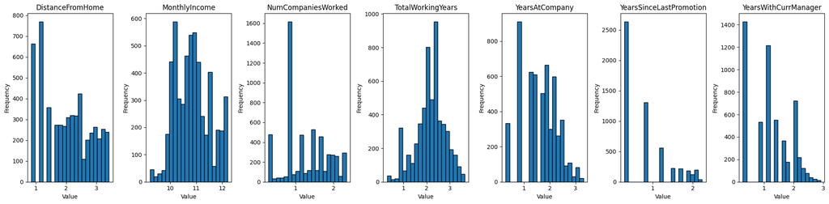

```python
# add 1/3 and take the log of the highly skewed x variables
import numpy as np
import pandas as pd
import matplotlib.pyplot as plt

# List of highly skewed columns
skewed_columns = ['DistanceFromHome', 'MonthlyIncome', 'NumCompaniesWorked', 'TotalWorkingYears', 'YearsAtCompany', 'YearsSinceLastPromotion','YearsWithCurrManager']

# Create a copy of the df_clean DataFrame
X_smote_log = X_smote.copy()

# Apply the logarithm transformation to the skewed columns with an offset of 1/3 in the new DataFrame
X_smote_log[skewed_columns] = X_smote_log[skewed_columns].apply(lambda x: np.log1p(x + 1/3))

# Create a figure with subplots
fig, axes = plt.subplots(nrows=1, ncols=len(skewed_columns), figsize=(20, 5))

# Iterate through columns and plot histograms from the new DataFrame
for i, column in enumerate(skewed_columns):
    axes[i].hist(X_smote_log[column], bins=20, edgecolor='k')
    axes[i].set_title(column)
    axes[i].set_xlabel('Value')
    axes[i].set_ylabel('Frequency')

plt.tight_layout()
plt.show()
```

```python
y_smote = y_smote.to_frame()
```

```python
# repeat all above changes to X_train/X_smote for X_test
X_test0['overtime_percentage'] = abs(((X_test0['avg_time'] - X_test0['StandardHours']) / X_test0['StandardHours']) * 100)
X_test0.drop(['avg_time', 'StandardHours'], axis=1, inplace=True)
X_test0[skewed_columns] = X_test0[skewed_columns].apply(lambda x: np.log1p(x + 1/3))
#y_test
y_test = y_test0.to_frame()
```

Polynomial terms

```python
from sklearn.preprocessing import PolynomialFeatures
from sklearn.linear_model import LinearRegression
from sklearn.model_selection import train_test_split
from sklearn.metrics import r2_score
import numpy as np

# Dependent variable
y = y_smote['Attrition']

# Continuous independent variables
features = ['Age', 'DistanceFromHome', 'MonthlyIncome', 'NumCompaniesWorked',
            'PercentSalaryHike','TotalWorkingYears',
            'TrainingTimesLastYear', 'YearsAtCompany', 'YearsSinceLastPromotion',
            'YearsWithCurrManager']

# Initialize polynomial feature variables
poly2 = PolynomialFeatures(degree=2)
poly3 = PolynomialFeatures(degree=3)

# Initialize linear regression model
model = LinearRegression()

# Loop through each feature
for feature in features:
    X = X_smote_log[[feature]]

    # Train-test split
    X_train, X_test, y_train, y_test = train_test_split(X, y, test_size=0.2, random_state=42)

    # Linear
    model.fit(X_train, y_train)
    y_pred = model.predict(X_test)
    r2_linear = r2_score(y_test, y_pred)

    # Quadratic
    X_poly2 = poly2.fit_transform(X_train)
    model.fit(X_poly2, y_train)
    y_pred = model.predict(poly2.transform(X_test))
    r2_quad = r2_score(y_test, y_pred)

    # Cubic
    X_poly3 = poly3.fit_transform(X_train)
    model.fit(X_poly3, y_train)
    y_pred = model.predict(poly3.transform(X_test))
    r2_cubic = r2_score(y_test, y_pred)

    print(f"{feature} - R2 linear: {r2_linear}, R2 quadratic: {r2_quad}, R2 cubic: {r2_cubic}")

# Results suggesting Age quadratic
```

```
Age - R2 linear: 0.0535607986488188, R2 quadratic: 0.06275349933319296, R2 cubic: 0.06214529898006005
DistanceFromHome - R2 linear: -0.00045553092192629485, R2 quadratic: -7.276844176340447e-05, R2 cubic: 0.001989582982250049
MonthlyIncome - R2 linear: 0.00032930691078603136, R2 quadratic: 0.0007194086810357048, R2 cubic: -2.3122110922590977e-05
NumCompaniesWorked - R2 linear: 0.00954868840110068, R2 quadratic: 0.0267588537531126, R2 cubic: 0.02819775449071993
PercentSalaryHike - R2 linear: -0.0005217405616722015, R2 quadratic: 0.014729454588185864, R2 cubic: 0.01475580785382602
TotalWorkingYears - R2 linear: 0.08789929160804766, R2 quadratic: 0.0923327158631293, R2 cubic: 0.09231289420758482
TrainingTimesLastYear - R2 linear: 0.040024182693519594, R2 quadratic: 0.054084550915826535, R2 cubic: 0.05509004003198237
YearsAtCompany - R2 linear: 0.12099888791795277, R2 quadratic: 0.12112993950066919, R2 cubic: 0.12062630593846602
YearsSinceLastPromotion - R2 linear: 0.004494547560004447, R2 quadratic: 0.005444757793433785, R2 cubic: 0.016818385950256642
YearsWithCurrManager - R2 linear: 0.10962399843982185, R2 quadratic: 0.11030585341749277, R2 cubic: 0.11644134732843303
```

```python
# Add quadratic term for 'Age'
X_smote_log['Age_squared'] = X_smote_log['Age'] ** 2
```

```python
# repeat all above changes to X_train/X_smote for X_test
X_test0['Age_squared'] = X_test0['Age'] ** 2
```

interaction terms

```python
from sklearn.linear_model import LinearRegression
from sklearn.model_selection import train_test_split
from sklearn.metrics import r2_score
import pandas as pd

# Dependent variable
y = y_smote['Attrition']

# Continuous independent variables
features = ['Age', 'DistanceFromHome', 'MonthlyIncome', 'NumCompaniesWorked',
            'PercentSalaryHike', 'TotalWorkingYears',
            'TrainingTimesLastYear', 'YearsAtCompany', 'YearsSinceLastPromotion',
            'YearsWithCurrManager', 'overtime_percentage']

# Initialize linear regression model
model = LinearRegression()

# Loop through each feature
for feature in features:
    X = X_smote_log[[feature]]

    # Train-test split
    X_train, X_test, y_train, y_test = train_test_split(X, y, test_size=0.2, random_state=42)
    model.fit(X_train, y_train)
    y_pred = model.predict(X_test)
    r2_without_interaction = r2_score(y_test, y_pred)

    # Interaction Terms
    for i in range(len(features)):
        if features[i] != feature:
            interaction_name = f'{feature}_x_{features[i]}'

            # Create a copy of the DataFrame to avoid warnings
            X_interaction = X_smote_log[[feature, features[i]]].copy()
            X_interaction['interaction'] = X_interaction[feature] * X_interaction[features[i]]
            X_train_int, X_test_int, y_train_int, y_test_int = train_test_split(X_interaction, y, test_size=0.2, random_state=42)
            model.fit(X_train_int, y_train_int)
            y_pred_int = model.predict(X_test_int)
            r2_interaction = r2_score(y_test_int, y_pred_int)

            # Check if the interaction term improves the model by at least 12.5%
            if r2_interaction > r2_without_interaction + 0.125:
                print(f"{interaction_name} - R2 interaction: {r2_interaction}. This interaction term is needed.")
            else:
                continue
```

```
NumCompaniesWorked_x_TotalWorkingYears - R2 interaction: 0.13774242344014853. This interaction term is needed.
overtime_percentage_x_YearsAtCompany - R2 interaction: 0.1203078193479481. This interaction term is needed.
```

```python
# Create the interaction terms
X_smote_log['NumCompaniesWorked_x_TotalWorkingYears'] = X_smote_log['NumCompaniesWorked'] * X_smote_log['TotalWorkingYears']
X_smote_log['overtime_percentage_x_YearsAtCompany'] = X_smote_log['overtime_percentage'] * X_smote_log['YearsAtCompany']
```

```python
X_smote_log
```

|  | id | Age | BusinessTravel | DistanceFromHome | Education | EmployeeCount | EmployeeID | Gender | JobLevel | MonthlyIncome | ... | JobRole_Laboratory Technician | JobRole_Manufacturing Director | JobRole_Research Director | JobRole_Research Scientist | JobRole_Sales Executive | JobRole_Sales Representative | overtime_percentage | Age_squared | NumCompaniesWorked_x_TotalWorkingYears | overtime_percentage_x_YearsAtCompany |
| --- | --- | --- | --- | --- | --- | --- | --- | --- | --- | --- | --- | --- | --- | --- | --- | --- | --- | --- | --- | --- | --- |
| 0 | 3870 | 38 | 3 | 3.012262 | 2 | 1 | 3870 | 1 | 2 | 10.106891 | ... | 0.000000 | 0.000000 | 0.0 | 1.0000 | 0.000000 | 0.000000 | 10.184852 | 1444 | 6.386788 | 27.118064 |
| 1 | 4143 | 29 | 2 | 1.845827 | 3 | 1 | 4143 | 1 | 2 | 11.232303 | ... | 0.000000 | 0.000000 | 0.0 | 0.0000 | 0.000000 | 1.000000 | 24.216420 | 841 | 1.563965 | 44.699314 |
| 2 | 2367 | 47 | 2 | 3.270836 | 4 | 1 | 2367 | 1 | 2 | 11.908484 | ... | 0.000000 | 0.000000 | 0.0 | 1.0000 | 0.000000 | 0.000000 | 24.857220 | 2209 | 4.903488 | 45.882120 |
| 3 | 4301 | 41 | 2 | 2.427748 | 4 | 1 | 4301 | 1 | 4 | 10.958345 | ... | 0.000000 | 0.000000 | 0.0 | 1.0000 | 0.000000 | 0.000000 | 0.091348 | 1681 | 2.552740 | 0.168613 |
| 4 | 524 | 26 | 2 | 1.845827 | 4 | 1 | 524 | 0 | 2 | 10.754094 | ... | 0.000000 | 0.000000 | 0.0 | 0.0000 | 1.000000 | 0.000000 | 6.032242 | 676 | 1.688182 | 11.134473 |
| ... | ... | ... | ... | ... | ... | ... | ... | ... | ... | ... | ... | ... | ... | ... | ... | ... | ... | ... | ... | ... | ... |
| 5485 | 2598 | 33 | 2 | 1.845827 | 4 | 1 | 2598 | 1 | 1 | 11.084268 | ... | 0.693567 | 0.000000 | 0.0 | 0.0000 | 0.000000 | 0.000000 | 25.523837 | 1089 | 4.876321 | 21.626293 |
| 5486 | 1443 | 29 | 2 | 1.203973 | 2 | 1 | 1443 | 0 | 1 | 10.815636 | ... | 0.000000 | 0.000000 | 0.0 | 0.0000 | 1.000000 | 0.000000 | 1.591111 | 841 | 0.962981 | 2.936915 |
| 5487 | 1774 | 34 | 2 | 1.203973 | 2 | 1 | 1774 | 0 | 4 | 10.715203 | ... | 0.000000 | 0.588352 | 0.0 | 0.0000 | 0.000000 | 0.411648 | 1.044936 | 1156 | 2.567280 | 0.885372 |
| 5488 | 2086 | 39 | 2 | 2.662588 | 3 | 1 | 2086 | 0 | 1 | 11.042767 | ... | 0.602316 | 0.000000 | 0.0 | 0.0000 | 0.397684 | 0.000000 | 16.064603 | 1521 | 2.168313 | 40.359192 |
| 5489 | 945 | 22 | 2 | 1.845827 | 3 | 1 | 945 | 0 | 3 | 10.813566 | ... | 0.973800 | 0.000000 | 0.0 | 0.0262 | 0.000000 | 0.000000 | 1.429944 | 484 | 1.549827 | 2.393693 |

5490 rows × 40 columns

```python
y_smote
```

|  | Attrition |
| --- | --- |
| 0 | 0 |
| 1 | 0 |
| 2 | 0 |
| 3 | 0 |
| 4 | 0 |
| ... | ... |
| 5485 | 1 |
| 5486 | 1 |
| 5487 | 1 |
| 5488 | 1 |
| 5489 | 1 |

5490 rows × 1 columns

```python
# repeat all above changes to X_train/X_smote for X_test

# Create the interaction terms
X_test0['NumCompaniesWorked_x_TotalWorkingYears'] = X_test0['NumCompaniesWorked'] * X_test0['TotalWorkingYears']
X_test0['overtime_percentage_x_YearsAtCompany'] = X_test0['overtime_percentage'] * X_test0['YearsAtCompany']
```

# Feature Selection

```python
# Drop index column
X_smote_log_dropped = X_smote_log.drop(['id', 'EmployeeID'], axis=1)
```

```python
# Drop employee count
X_smote = X_smote_log_dropped.drop(['EmployeeCount'], axis=1)
```

```python
# repeat all above changes to X_train/X_smote for X_test
X_test_log_dropped = X_test0.drop(['id', 'EmployeeID'], axis=1)
X_test0 = X_test_log_dropped.drop(['EmployeeCount'], axis=1)
```

```python
X_smote.columns
```

```
Index(['Age', 'BusinessTravel', 'DistanceFromHome', 'Education', 'Gender',
       'JobLevel', 'MonthlyIncome', 'NumCompaniesWorked', 'Over18',
       'PercentSalaryHike', 'StockOptionLevel', 'TotalWorkingYears',
       'TrainingTimesLastYear', 'YearsAtCompany', 'YearsSinceLastPromotion',
       'YearsWithCurrManager', 'Department_Human Resources',
       'Department_Sales', 'EducationField_Human Resources',
       'EducationField_Life Sciences', 'EducationField_Marketing',
       'EducationField_Medical', 'EducationField_Technical Degree',
       'MaritalStatus_Divorced', 'MaritalStatus_Married',
       'JobRole_Healthcare Representative', 'JobRole_Human Resources',
       'JobRole_Laboratory Technician', 'JobRole_Manufacturing Director',
       'JobRole_Research Director', 'JobRole_Research Scientist',
       'JobRole_Sales Executive', 'JobRole_Sales Representative',
       'overtime_percentage', 'Age_squared',
       'NumCompaniesWorked_x_TotalWorkingYears',
       'overtime_percentage_x_YearsAtCompany'],
      dtype='object')
```

```python
y_smote.columns
```

```
Index(['Attrition'], dtype='object')
```

# Step 3. Modeling

Make sure to use the correct variables for each modeling step; all variables (transformed and not) are in the df!

## Decision Tree

### Setup

```python
############################### Import Libraries & Modules #################################
from sklearn.tree import DecisionTreeClassifier # A decision tree classifier
# GridSearchCV performs an exhaustive search over specified parameter values for an estimator
# The parameters of the estimator used to apply these methods are optimized by cross-validated
# grid-search over a parameter grid.
# Documentation: http://scikit-learn.org/stable/modules/generated/sklearn.model_selection.GridSearchCV.html
from sklearn.model_selection import GridSearchCV, KFold, cross_val_score
from sklearn.linear_model import LogisticRegression
from sklearn.neighbors import KNeighborsClassifier
from sklearn import neighbors, datasets
# Standardize features by removing the mean and scaling to unit variance
from sklearn.preprocessing import StandardScaler
# Pipeline of transforms with a final estimator
from sklearn.pipeline import Pipeline


np.random.seed(42) # ensure reproducability
```

### Initiate Cross Validation

```python
################################# Nested Cross-Validation #################################

##################################### Parameter Tuning ####################################

# Exhaustive search over specified parameter values for an estimator.
# GridSearchCV implements a “fit” and a “score” method.
# It also implements “predict”, “predict_proba”, “decision_function”, “transform” and “inverse_transform”
# if they are implemented in the estimator used.

# The parameters of the estimator used to apply these methods are optimized by cross-validated
# grid-search over a parameter grid.
# KFold splits dataset into k consecutive folds (without shuffling by default)

inner_cv = KFold(n_splits=5, shuffle=True, random_state = 42) # inner cross-validation folds
outer_cv = KFold(n_splits=5, shuffle=True, random_state = 42) # outer cross-validation folds
```

### Parameter Tuning

```python
############################## Decision Tree Parameter Tuning ##############################

# Create max_depth list for later
max_depth = [None, 1, 3, 5, 7, 10, 12, 15, 17, 20, 23, 25, 30, 35, 40]

gs_dt2 = GridSearchCV(estimator=DecisionTreeClassifier(random_state=42),
                  param_grid=[{'max_depth': max_depth,
                               'criterion':['gini','entropy'],
                               'min_samples_leaf':[1,2,3,4,5],
                               'min_samples_split':[2,3,4,5]}],
                  scoring='accuracy',
                  cv=inner_cv,
                  n_jobs=-1)

gs_dt2 = gs_dt2.fit(X_smote,y_smote)
print("\n Parameter Tuning #3")
print("Non-nested CV Accuracy: ", gs_dt2.best_score_)
print("Optimal Parameter: ", gs_dt2.best_params_)
print("Optimal Estimator: ", gs_dt2.best_estimator_)
nested_score_gs_dt2 = cross_val_score(gs_dt2, X=X_test0, y=y_test0, cv=outer_cv)
print("Nested CV Accuracy: ",nested_score_gs_dt2.mean(), " +/- ", nested_score_gs_dt2.std())
```

```
 Parameter Tuning #3
Non-nested CV Accuracy:  0.9677595628415301
Optimal Parameter:  {'criterion': 'entropy', 'max_depth': 20, 'min_samples_leaf': 1, 'min_samples_split': 3}
Optimal Estimator:  DecisionTreeClassifier(criterion='entropy', max_depth=20, min_samples_split=3,
                       random_state=42)
Nested CV Accuracy:  0.8278916654197216  +/-  0.029741857836939237
```

## KNN

### Setup

#### Normalize Data

```python
#Normalize Data
pipe = Pipeline([
        ('sc', StandardScaler()),
        ('knn', KNeighborsClassifier(p=2,
                                     metric='minkowski'))
      ])
```

### k-NN Parameter Tuning

```python
################################### kNN Parameter Tuning ###################################

#Parameters to optimize
params = {
        'knn__n_neighbors': list(range(1, 30))
    }

#Parameters to optimize:  k for number of nearest neighbors AND type of distance

params = {
        'knn__n_neighbors': list(range(1, 30)),
        'knn__weights': ['uniform', 'distance']
    }

gs_knn2 = GridSearchCV(estimator=pipe,
                  param_grid=params,
                  scoring='accuracy',
                  cv=inner_cv,
                  n_jobs=4)

gs_knn2 = gs_knn2.fit(X_smote,y_smote.values.ravel())
print("\n Parameter Tuning")
print("Non-nested CV Accuracy: ", gs_knn2.best_score_)
print("Optimal Parameter: ", gs_knn2.best_params_)
print("Optimal Estimator: ", gs_knn2.best_estimator_) # Estimator that was chosen by the search, i.e. estimator which gave highest score
nested_score_gs_knn2 = cross_val_score(gs_knn2, X=X_test0, y=y_test0.values.ravel(), cv=outer_cv)
print("Nested CV Accuracy: ",nested_score_gs_knn2.mean(), " +/- ", nested_score_gs_knn2.std())
```

[output not shown]

## Logistic Regression

### Parameter Tuning

```python
############################ Logistic Regression Parameter Tuning ############################
#To ignore the convergence warnings
from  warnings import simplefilter
from sklearn.exceptions import ConvergenceWarning
simplefilter("ignore", category=ConvergenceWarning)

# Choosing C parameter for Logistic Regression AND type of penalty (ie., l1 vs l2)
# See other parameters here http://scikit-learn.org/stable/modules/generated/sklearn.linear_model.LogisticRegression.html
gs_lr2 = GridSearchCV(estimator=LogisticRegression(random_state=42, solver='liblinear'),
                  param_grid=[{'C': [ 0.00001, 0.0001, 0.001, 0.01, 0.1 ,1 ,10 ,100, 1000, 10000, 100000, 1000000, 10000000],
                              'penalty':['l1','l2']}],
                  scoring='accuracy',
                  cv=inner_cv)

gs_lr2 = gs_lr2.fit(X_smote,y_smote.values.ravel())
print("\n Parameter Tuning #5")
print("Non-nested CV Accuracy: ", gs_lr2.best_score_)
print("Optimal Parameter: ", gs_lr2.best_params_)
print("Optimal Estimator: ", gs_lr2.best_estimator_)

nested_score_gs_lr2 = cross_val_score(gs_lr2, X=X_test0, y=y_test0.values.ravel(), cv=outer_cv)
print("Nested CV Accuracy:",nested_score_gs_lr2.mean(), " +/- ", nested_score_gs_lr2.std())
```

```
 Parameter Tuning #5
Non-nested CV Accuracy:  0.766848816029144
Optimal Parameter:  {'C': 1, 'penalty': 'l2'}
Optimal Estimator:  LogisticRegression(C=1, random_state=42, solver='liblinear')
Nested CV Accuracy: 0.842525811761185  +/-  0.01483010789128791
```

# Evaluation

gs_dt2

DecisionTreeClassifier(criterion='entropy', max_depth=20, min_samples_split=3, random_state=42)

gs_knn2

Pipeline(steps=[('sc', StandardScaler()), ('knn', KNeighborsClassifier(n_neighbors=2))])

gs_lr2

LogisticRegression(C=1, random_state=42, solver='liblinear')

```python
# Define the plot_confusion_matrix function
def plot_confusion_matrix(cm, classes,
                          normalize=False,
                          title='Confusion matrix',
                          cmap=plt.cm.Blues):
    """
    This function prints and plots the confusion matrix.
    Normalization can be applied by setting `normalize=True`.
    """
    if normalize:
        cm = cm.astype('float') / cm.sum(axis=1)[:, np.newaxis]  # Normalize the confusion matrix
        print("Normalized confusion matrix")
    else:
        print('Confusion matrix, without normalization')

    print(cm)

    plt.imshow(cm, interpolation='nearest', cmap=cmap)
    plt.title(title)
    plt.colorbar()
    tick_marks = np.arange(len(classes))
    plt.xticks(tick_marks, classes, rotation=45)
    plt.yticks(tick_marks, classes)

    fmt = '.2f' if normalize else 'd'
    thresh = cm.max() / 2.
    for i, j in itertools.product(range(cm.shape[0]), range(cm.shape[1])):
        plt.text(j, i, format(cm[i, j], fmt),
                 horizontalalignment="center",
                 color="white" if i==j else "black")

    plt.tight_layout()
    plt.ylabel('True label')
    plt.xlabel('Predicted label')
```

```
f1:  0.9697029160507507
recall:  0.9694749694749695
Confusion matrix, without normalization
[[672  15]
 [ 10 122]]
Normalized confusion matrix
[[0.98 0.02]
 [0.08 0.92]]
```

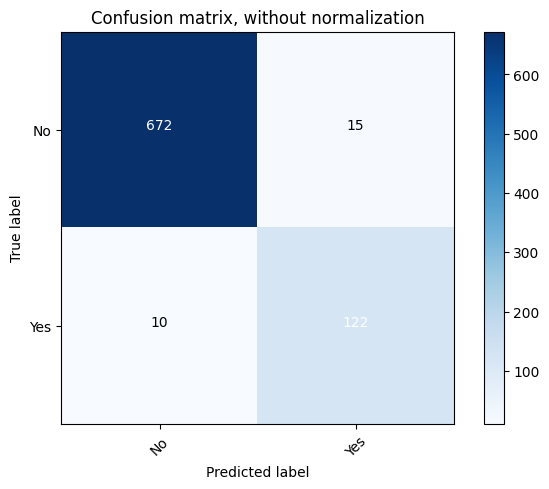

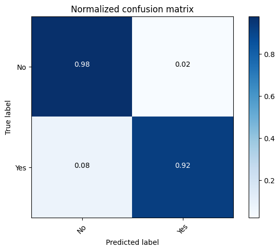

```python
from sklearn.metrics import confusion_matrix
import itertools
from sklearn.metrics import f1_score
from sklearn.metrics import recall_score

y_pred1 = gs_dt2.predict(X_test0)
cnf_matrix1 = confusion_matrix(y_test0, y_pred1)

# Determine the way floating point numbers are displayed
np.set_printoptions(precision=2)

print("f1: ",f1_score(y_test0, y_pred1, average='weighted'))
print("recall: ",recall_score(y_test0, y_pred1, average='weighted'))

# Plot non-normalized confusion matrix
plt.figure()
plot_confusion_matrix(cnf_matrix1,
                      classes=["No", "Yes"],  # Replace with your actual class names
                      title='Confusion matrix, without normalization')

# Plot normalized confusion matrix
plt.figure()
plot_confusion_matrix(cnf_matrix1,
                      classes=["No", "Yes"],  # Replace with your actual class names
                      normalize=True,
                      title='Normalized confusion matrix')

plt.show()
```

```
f1:  0.9963199347918752
recall:  0.9963369963369964
Confusion matrix, without normalization
[[687   0]
 [  3 129]]
Normalized confusion matrix
[[1.   0.  ]
 [0.02 0.98]]
```

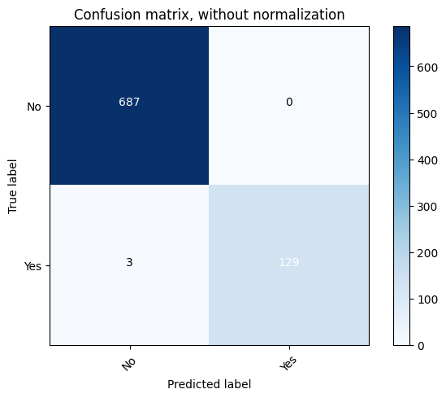

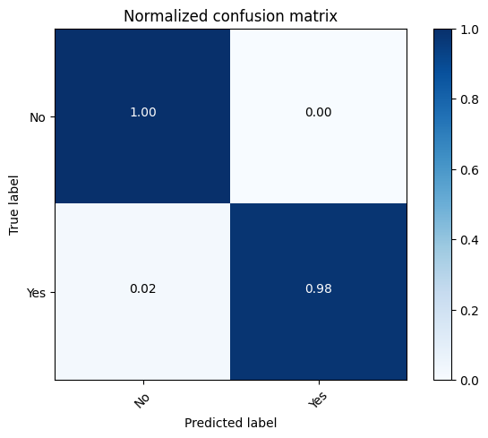

```python
from sklearn.metrics import confusion_matrix
import itertools
y_pred2 = gs_knn2.predict(X_test0)
cnf_matrix2 = confusion_matrix(y_test0, y_pred2)

# Determine the way floating point numbers are displayed
np.set_printoptions(precision=2)


print("f1: ",f1_score(y_test0, y_pred2, average='weighted'))
print("recall: ",recall_score(y_test0, y_pred2, average='weighted'))

# Plot non-normalized confusion matrix
plt.figure()
plot_confusion_matrix(cnf_matrix2,
                      classes=["No", "Yes"],
                      title='Confusion matrix, without normalization')

# Plot normalized confusion matrix
plt.figure()
plot_confusion_matrix(cnf_matrix2,
                      classes=["No", "Yes"],
                      normalize=True,
                      title='Normalized confusion matrix')

plt.show()
```

```
f1:  0.7555333206824573
recall:  0.7289377289377289
Confusion matrix, without normalization
[[526 161]
 [ 61  71]]
Normalized confusion matrix
[[0.77 0.23]
 [0.46 0.54]]
```

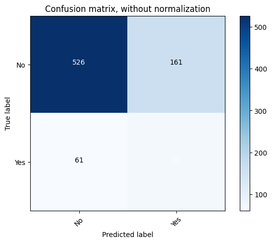

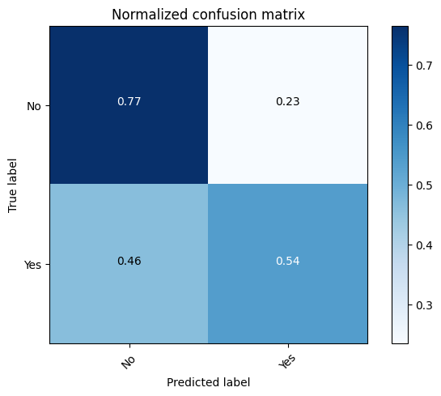

```python
y_pred3 = gs_lr2.predict(X_test0)
cnf_matrix3 = confusion_matrix(y_test0, y_pred3)

# Determine the way floating point numbers are displayed
np.set_printoptions(precision=2)


print("f1: ",f1_score(y_test0, y_pred3, average='weighted'))
print("recall: ",recall_score(y_test0, y_pred3, average='weighted'))

# Plot non-normalized confusion matrix
plt.figure()
plot_confusion_matrix(cnf_matrix3,
                      classes=["No", "Yes"],
                      title='Confusion matrix, without normalization')

# Plot normalized confusion matrix
plt.figure()
plot_confusion_matrix(cnf_matrix3,
                      classes=["No", "Yes"],
                      normalize=True,
                      title='Normalized confusion matrix')

plt.show()
```

### expected value

Identify Costs and Benefits

Identify all the costs and benefits associated with the classifier's predictions. These can include:

- True Positives (TP): Employees correctly identified as at risk, leading to a benefit (e.g., cost savings from retaining a valuable employee).
- False Positives (FP): Employees incorrectly identified as at risk, incurring costs (e.g., unnecessary retention efforts).
- True Negatives (TN): Employees correctly identified as not at risk, with no direct cost or benefit.
- False Negatives (FN): Employees incorrectly identified as not at risk, potentially leading to attrition costs.

Costs of implementing and maintaining the classifier (e.g., software, personnel).

Assign monetary values to each cost and benefit. This can be challenging for non-financial factors, but it's essential for quantifying the expected value. For example: Benefit of retaining a valuable employee: Estimated annual salary and productivity value. Cost of implementing the classifier: Costs associated with software, training, and maintenance.

```python
cnf_matrix1/np.sum(cnf_matrix1)
```

```
array([[0.82, 0.02],
       [0.01, 0.15]])
```

```python
import numpy as np

matrix = np.array([
    [0, -1010],
    [0, 80000*.35-10-1000]
])

print(matrix*(cnf_matrix1/np.sum(cnf_matrix1)))
print(np.sum(matrix*(cnf_matrix1/np.sum(cnf_matrix1))))
```

```
[[   0.          -18.4981685 ]
 [   0.         4020.48840049]]
4001.990231990232
```

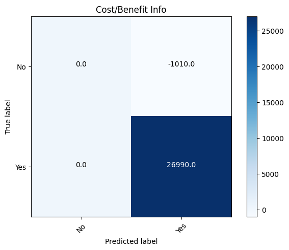

```python
import matplotlib.pyplot as plt
from sklearn.metrics import confusion_matrix
import itertools

plt.figure()
cm = matrix
classes=["No", "Yes"]
title='Cost/Benefit Info'

plt.imshow(cm, interpolation='nearest', cmap=plt.cm.Blues)
plt.title(title)
plt.colorbar()
tick_marks = np.arange(len(classes))
plt.xticks(tick_marks, classes, rotation=45)
plt.yticks(tick_marks, classes)

thresh = cm.max() / 2.
for i, j in itertools.product(range(cm.shape[0]), range(cm.shape[1])):
    plt.text(j, i, format(cm[i, j]),
              horizontalalignment="center",
              color="white" if (i==1 and j ==1) else "black")
plt.tight_layout()
plt.ylabel('True label')
plt.xlabel('Predicted label')

plt.show()
```

### plotting

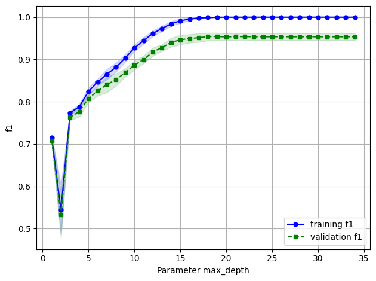

```python
#c)	Build a fitting graph for different depths of the decision tree (visualize the performance for both training and test data in the same plot). Please provide screenshots of your code and explain the process you have followed.

############################### Import Libraries & Modules #################################

# Fitting curve (aka validation curve)
# Determine training and test scores for varying parameter values.
from sklearn.model_selection import validation_curve
# Split validation
from sklearn.model_selection import train_test_split
from sklearn.model_selection import ShuffleSplit
# Class for Logistic Regression classifier

############################# Parameters - Varying Complexity #############################

param_range = range(1,35)

# Compute scores for an estimator with different values of a specified parameter.
# This is similar to grid search with one parameter.
# However, this will also compute training scores and is merely a utility for plotting the results.

########################## Estimate Scores - Varying Complexity ##########################
cv = ShuffleSplit(n_splits=10,          # number of re-shuffling & splitting iterations
                  test_size=0.3
                  ,random_state=42)
# Determine training and test scores for varying parameter values.
# sklearn documentation https://scikit-learn.org/stable/modules/generated/sklearn.model_selection.validation_curve.html
train_scores, test_scores = validation_curve(
                estimator=DecisionTreeClassifier(criterion='entropy', random_state=42),
                X=X_smote,                                    # data (features)
                y=y_smote,                                    # target variable
                param_name="max_depth",
                param_range=param_range,                      # the values of the parameter that will be evaluated

                cv=cv,                                        # 10-fold cross-validation
                scoring="f1",                           # evaluation metric
                n_jobs=1)         # number of CPU cores used when parallelizing over classes if multi_class=’ovr’”.
                                  # this parameter is ignored when the ``solver``is set to ‘liblinear’ regardless of
                                  # whether ‘multi_class’ is specified or not. If given a value of -1, all cores are used.

# Cross validation statistics for training and testing data (mean and standard deviation)
train_mean = np.mean(train_scores, axis=1) # compute the arithmetic mean along the specified axis (train data)
train_std = np.std(train_scores, axis=1)   # compute the standard deviation along the specified axis (train data)
test_mean = np.mean(test_scores, axis=1)   # compute the arithmetic mean along the specified axis (test data)
test_std = np.std(test_scores, axis=1)     # compute the standard deviation along the specified axis (test data)

############################## Visualization - Fitting Graph ##############################

# Plot train f1 means of cross-validation for all the parameters C in param_range
plt.plot(param_range,                     # the horizontal coordinates of the data points
         train_mean,                      # the vertical coordinates of the data points
         color='blue',                    # aesthetic parameter - color
         marker='o',                      # aesthetic parameter - marker
         markersize=5,                    # aesthetic parameter - size of marker
         label='training f1')       # specify label title

# Fill the area around the line to indicate the size of standard deviations of performance for the training data
plt.fill_between(param_range,             # the x coordinates of the nodes defining the curves
                 train_mean + train_std,  # the y coordinates of the nodes defining the first curve
                 train_mean - train_std,  # the y coordinates of the nodes defining the second curve
                 alpha=0.15,              # level of transparency in the color fill
                 color='blue')            # aesthetic parameter - color

# Plot test accuracy means of cross-validation for all the parameters C in param_range
plt.plot(param_range,
         test_mean,
         color='green',
         linestyle='--',
         marker='s',
         markersize=5,
         label='validation f1')

# Fill the area around the line to indicate the size of standard deviations of performance for the test data
plt.fill_between(param_range,
                 test_mean + test_std,
                 test_mean - test_std,
                 alpha=0.15, color='green')

# Grid and Axes Titles
plt.grid()
plt.legend(loc='lower right')
plt.xlabel('Parameter max_depth')
plt.ylabel('f1')
#plt.ylim([0.9, 1.0]) # y limits in the plot
plt.tight_layout()
#plt.savefig('Fitting_graph_LR.png', dpi=300)
plt.show()                            # display the figure
```

```
10-fold cross validation:

ROC AUC: 0.8417 (+/- 0.0091) [Logistic regression]
ROC AUC: 0.9545 (+/- 0.0077) [Decision tree]
ROC AUC: 0.9740 (+/- 0.0065) [kNN]
```

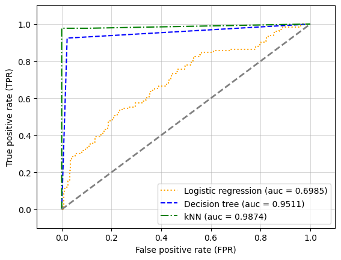

```python
#d)	Create an ROC curve for k-NN, decision tree, and logistic regression

############################### Import Libraries & Modules #################################

import numpy as np
from sklearn.metrics import roc_curve
from sklearn.metrics import auc

######################################## Classifiers ########################################
# Logistic Regression Classifier                                                 ---------------------------------------- replaced wtih result of a
clf1 = LogisticRegression(C=1, random_state=42, solver='liblinear')

# Decision Tree Classifier
clf2 =DecisionTreeClassifier(criterion='entropy', max_depth=20, min_samples_split=3,
                       random_state=42)
# kNN Classifier

clf3 = Pipeline(steps=[('sc', StandardScaler()),
                ('knn', KNeighborsClassifier(n_neighbors=2))])

# Label the classifiers
clf_labels = ['Logistic regression', 'Decision tree', 'kNN']
all_clf = [clf1, clf2, clf3]


#################################### Cross - Validation ####################################

print('10-fold cross validation:\n')

for clf, label in zip([clf1, clf2, clf3], clf_labels): #For all classifiers

        scores = cross_val_score(estimator=clf,  # estimate AUC based on cross validation
                             X=X_smote,
                             y=y_smote.values.ravel(),
                             cv=cv,
                             scoring='roc_auc')

        print("ROC AUC: %0.4f (+/- %0.4f) [%s]" # print peformance statistics based on cross-validation
          % (scores.mean(), scores.std(), label))

##################################### Visualization ######################################

colors = [ 'orange', 'blue', 'green']      # colors for visualization
linestyles = [':', '--', '-.', '-']        # line styles for visualization
for clf, label, clr, ls in zip(all_clf,
               clf_labels, colors, linestyles):

      y_pred = clf.fit(X_smote, y_smote.values.ravel()).predict_proba(X_test0)[:, 1] # make predictions based on the classifiers

      fpr, tpr, thresholds = roc_curve(y_true=y_test0,       # build ROC curve
                                      y_score=y_pred)
      roc_auc = auc(x=fpr, y=tpr)                           # compute Area Under the Curve (AUC)
      plt.plot(fpr, tpr,                                    # plot ROC Curve and create label with AUC values
              color=clr,
              linestyle=ls,
              label='%s (auc = %0.4f)' % (label, roc_auc))

plt.legend(loc='lower right')    # where to place the legend
plt.plot([0, 1], [0, 1],         # visualize random classifier
         linestyle='--',         # aesthetic parameters
         color='gray',
         linewidth=2)

plt.xlim([-0.1, 1.1])   #limits for x axis
plt.ylim([-0.1, 1.1])   #limits for y axis
plt.grid(alpha=0.5)
plt.xlabel('False positive rate (FPR)')
plt.ylabel('True positive rate (TPR)')

#plt.savefig('ROC_all_classifiers', dpi=300)
plt.show()
```

# Feedback Loop

This is a fairly rough idea of what our feedback loop mechanism might look like. These functions take a dataframe, including all of our data (ie an up to data dataframe) and process is correctly. Our second function takes the new data and performs parameter tuning to create a new, optimal model. We could read the dictionary outputs of our function to continuously perform model evaluation on the new models.

```python
import numpy as np
from sklearn.tree import DecisionTreeClassifier
from sklearn.model_selection import GridSearchCV, KFold, cross_val_score
from sklearn.linear_model import LogisticRegression
from sklearn.neighbors import KNeighborsClassifier
from sklearn.preprocessing import StandardScaler
from sklearn.pipeline import Pipeline
from warnings import simplefilter
from sklearn.exceptions import ConvergenceWarning

from sklearn.preprocessing import LabelEncoder

# We can use the prepare_data function to prep our data for incorporation into modeling later
def prepare_data(df):
    # Encoding categorical variables
    label_encoders = {}
    categorical_cols = ['BusinessTravel', 'Department', 'EducationField', 'MaritalStatus', 'JobRole']

    for col in categorical_cols:
        le = LabelEncoder()
        df[col] = le.fit_transform(df[col])
        label_encoders[col] = le

    # Drop reference level columns for one-hot encoded variables
    df.drop(['Department_Research & Development', 'EducationField_Other',
             'MaritalStatus_Single', 'JobRole_Manager'], axis=1, inplace=True)

    # Handle outliers
    df_clean = drop_outliers(df, cont_cols)

    # Map 'Attrition' to binary values
    df_clean['Attrition'] = df_clean['Attrition'].map({'Yes': 1, 'No': 0})

    # Train-test split
    X = df_clean.drop(['Attrition', 'EducationField', 'Department', 'MaritalStatus', 'JobRole'], axis=1)
    y = df_clean['Attrition']
    X_train, X_test0, y_train, y_test0 = train_test_split(X, y, test_size=0.2, random_state=42, stratify=y)

    # SMOTE for handling class imbalance
    smote = SMOTE(random_state=42)
    X_smote, y_smote = smote.fit_resample(X_train, y_train)

    # Adding new feature 'overtime_percentage'
    X_smote['overtime_percentage'] = abs(((X_smote['avg_time'] - X_smote['StandardHours']) / X_smote['StandardHours']) * 100)
    X_test0['overtime_percentage'] = abs(((X_test0['avg_time'] - X_test0['StandardHours']) / X_test0['StandardHours']) * 100)

    # Add squared term for 'Age'
    X_smote['Age_squared'] = X_smote['Age'] ** 2
    X_test0['Age_squared'] = X_test0['Age'] ** 2

    # Create interaction terms
    X_smote['NumCompaniesWorked_x_TotalWorkingYears'] = X_smote['NumCompaniesWorked'] * X_smote['TotalWorkingYears']
    X_smote['overtime_percentage_x_YearsAtCompany'] = X_smote['overtime_percentage'] * X_smote['YearsAtCompany']

    X_test0['NumCompaniesWorked_x_TotalWorkingYears'] = X_test0['NumCompaniesWorked'] * X_test0['TotalWorkingYears']
    X_test0['overtime_percentage_x_YearsAtCompany'] = X_test0['overtime_percentage'] * X_test0['YearsAtCompany']

    return X_smote, y_smote, X_test0, y_test0, label_encoders

def train_models(X_train, y_train, X_test, y_test):
    np.random.seed(42)

    inner_cv = KFold(n_splits=5, shuffle=True, random_state=42)
    outer_cv = KFold(n_splits=5, shuffle=True, random_state=42)

    # Decision Tree Parameter Tuning
    max_depth = [None, 1, 3, 5, 7, 10, 12, 15, 17, 20, 23, 25, 30, 35, 40]
    gs_dt = GridSearchCV(estimator=DecisionTreeClassifier(random_state=42),
                        param_grid=[{'max_depth': max_depth,
                                    'criterion': ['gini', 'entropy'],
                                    'min_samples_leaf': [1, 2, 3, 4, 5],
                                    'min_samples_split': [2, 3, 4, 5]}],
                        scoring='accuracy',
                        cv=inner_cv,
                        n_jobs=-1)
    gs_dt.fit(X_train, y_train)
    dt_score = gs_dt.score(X_test, y_test)

    # k-NN Parameter Tuning
    pipe = Pipeline([
        ('sc', StandardScaler()),
        ('knn', KNeighborsClassifier(p=2, metric='minkowski'))
    ])

    params = {
        'knn__n_neighbors': list(range(1, 30)),
        'knn__weights': ['uniform', 'distance']
    }

    gs_knn = GridSearchCV(estimator=pipe,
                          param_grid=params,
                          scoring='accuracy',
                          cv=inner_cv,
                          n_jobs=4)
    gs_knn.fit(X_train, y_train)
    knn_score = gs_knn.score(X_test, y_test)

    # Logistic Regression Parameter Tuning
    simplefilter("ignore", category=ConvergenceWarning)
    gs_lr = GridSearchCV(estimator=LogisticRegression(random_state=42, solver='liblinear'),
                         param_grid=[{'C': [0.00001, 0.0001, 0.001, 0.01, 0.1, 1, 10, 100, 1000, 10000, 100000, 1000000, 10000000],
                                     'penalty': ['l1', 'l2']}],
                         scoring='accuracy',
                         cv=inner_cv)
    gs_lr.fit(X_train, y_train)
    lr_score = gs_lr.score(X_test, y_test)

    return dt_score, knn_score, lr_score, gs_dt.best_params_, gs_knn.best_params_, gs_lr.best_params_

# Assuming we have the new data in a DataFrame called `new_data_df`
X_smote, y_smote, X_test0, y_test0, label_encoders = prepare_data(new_data_df)

# Now we can use X_smote, y_smote, X_test0, y_test0 in the train_models function
dt_score, knn_score, lr_score, dt_params, knn_params, lr_params = train_models(X_smote, y_smote, X_test0, y_test0)
print("Decision Tree Score:", dt_score)
print("Decision Tree Best Parameters:", dt_params)
print("k-NN Score:", knn_score)
print("k-NN Best Parameters:", knn_params)
print("Logistic Regression Score:", lr_score)
print("Logistic Regression Best Parameters:", lr_params)
```